# Risk Factor Analysis

## Outcome Variable

**Outcome Variable:** ever_stunted

## Predictor Variables

**Intervention Variable:** hhwealth_quart

**Adjustment Set:**

unadjusted

## Stratifying Variables

The analysis was stratified on these variable(s):

- agecat
- studyid
- country

## Data Summary

| agecat | studyid | country | A | n | nA | nAY0 | nAY1 |
| --- | --- | --- | --- | --- | --- | --- | --- |
| 3 months | ki0047075b-MAL-ED | BANGLADESH | Wealth Q4 | 82 | 26 | 22 | 4 |
| 3 months | ki0047075b-MAL-ED | BANGLADESH | Wealth Q1 | 82 | 4 | 2 | 2 |
| 3 months | ki0047075b-MAL-ED | BANGLADESH | Wealth Q2 | 82 | 15 | 12 | 3 |
| 3 months | ki0047075b-MAL-ED | BANGLADESH | Wealth Q3 | 82 | 37 | 23 | 14 |
| 3 months | ki0047075b-MAL-ED | BRAZIL | Wealth Q4 | 3 | 2 | 0 | 2 |
| 3 months | ki0047075b-MAL-ED | BRAZIL | Wealth Q1 | 3 | 0 | 0 | 0 |
| 3 months | ki0047075b-MAL-ED | BRAZIL | Wealth Q2 | 3 | 1 | 0 | 1 |
| 3 months | ki0047075b-MAL-ED | BRAZIL | Wealth Q3 | 3 | 0 | 0 | 0 |
| 3 months | ki0047075b-MAL-ED | INDIA | Wealth Q4 | 71 | 29 | 21 | 8 |
| 3 months | ki0047075b-MAL-ED | INDIA | Wealth Q1 | 71 | 1 | 1 | 0 |
| 3 months | ki0047075b-MAL-ED | INDIA | Wealth Q2 | 71 | 10 | 7 | 3 |
| 3 months | ki0047075b-MAL-ED | INDIA | Wealth Q3 | 71 | 31 | 22 | 9 |
| 3 months | ki0047075b-MAL-ED | NEPAL | Wealth Q4 | 42 | 21 | 15 | 6 |
| 3 months | ki0047075b-MAL-ED | NEPAL | Wealth Q1 | 42 | 11 | 9 | 2 |
| 3 months | ki0047075b-MAL-ED | NEPAL | Wealth Q2 | 42 | 6 | 5 | 1 |
| 3 months | ki0047075b-MAL-ED | NEPAL | Wealth Q3 | 42 | 4 | 3 | 1 |
| 3 months | ki0047075b-MAL-ED | PERU | Wealth Q4 | 37 | 1 | 1 | 0 |
| 3 months | ki0047075b-MAL-ED | PERU | Wealth Q1 | 37 | 24 | 15 | 9 |
| 3 months | ki0047075b-MAL-ED | PERU | Wealth Q2 | 37 | 11 | 6 | 5 |
| 3 months | ki0047075b-MAL-ED | PERU | Wealth Q3 | 37 | 1 | 1 | 0 |
| 3 months | ki0047075b-MAL-ED | SOUTH AFRICA | Wealth Q4 | 68 | 13 | 10 | 3 |
| 3 months | ki0047075b-MAL-ED | SOUTH AFRICA | Wealth Q1 | 68 | 12 | 10 | 2 |
| 3 months | ki0047075b-MAL-ED | SOUTH AFRICA | Wealth Q2 | 68 | 24 | 22 | 2 |
| 3 months | ki0047075b-MAL-ED | SOUTH AFRICA | Wealth Q3 | 68 | 19 | 11 | 8 |
| 3 months | ki0047075b-MAL-ED | TANZANIA, UNITED REPUBLIC OF | Wealth Q4 | 60 | 0 | 0 | 0 |
| 3 months | ki0047075b-MAL-ED | TANZANIA, UNITED REPUBLIC OF | Wealth Q1 | 60 | 39 | 30 | 9 |
| 3 months | ki0047075b-MAL-ED | TANZANIA, UNITED REPUBLIC OF | Wealth Q2 | 60 | 21 | 15 | 6 |
| 3 months | ki0047075b-MAL-ED | TANZANIA, UNITED REPUBLIC OF | Wealth Q3 | 60 | 0 | 0 | 0 |
| 3 months | ki1000108-CMC-V-BCS-2002 | INDIA | Wealth Q4 | 362 | 92 | 47 | 45 |
| 3 months | ki1000108-CMC-V-BCS-2002 | INDIA | Wealth Q1 | 362 | 90 | 71 | 19 |

[output cut: 286 more lines]

The following strata were considered:

- agecat: 12 months, studyid: ki0047075b-MAL-ED, country: BANGLADESH
- agecat: 12 months, studyid: ki0047075b-MAL-ED, country: BRAZIL
- agecat: 12 months, studyid: ki0047075b-MAL-ED, country: INDIA
- agecat: 12 months, studyid: ki0047075b-MAL-ED, country: NEPAL
- agecat: 12 months, studyid: ki0047075b-MAL-ED, country: PERU
- agecat: 12 months, studyid: ki0047075b-MAL-ED, country: SOUTH AFRICA
- agecat: 12 months, studyid: ki0047075b-MAL-ED, country: TANZANIA, UNITED REPUBLIC OF
- agecat: 12 months, studyid: ki1000108-CMC-V-BCS-2002, country: INDIA
- agecat: 12 months, studyid: ki1000108-IRC, country: INDIA
- agecat: 12 months, studyid: ki1017093b-PROVIDE, country: BANGLADESH
- agecat: 12 months, studyid: ki1066203-TanzaniaChild2, country: TANZANIA, UNITED REPUBLIC OF
- agecat: 12 months, studyid: ki1113344-GMS-Nepal, country: NEPAL
- agecat: 12 months, studyid: ki1114097-CONTENT, country: PERU
- agecat: 12 months, studyid: ki1135781-COHORTS, country: GUATEMALA
- agecat: 12 months, studyid: ki1135781-COHORTS, country: PHILIPPINES
- agecat: 12 months, studyid: ki1148112-LCNI-5, country: MALAWI
- agecat: 18 months, studyid: ki0047075b-MAL-ED, country: BANGLADESH
- agecat: 18 months, studyid: ki0047075b-MAL-ED, country: BRAZIL
- agecat: 18 months, studyid: ki0047075b-MAL-ED, country: INDIA
- agecat: 18 months, studyid: ki0047075b-MAL-ED, country: NEPAL
- agecat: 18 months, studyid: ki0047075b-MAL-ED, country: PERU
- agecat: 18 months, studyid: ki0047075b-MAL-ED, country: SOUTH AFRICA
- agecat: 18 months, studyid: ki0047075b-MAL-ED, country: TANZANIA, UNITED REPUBLIC OF
- agecat: 18 months, studyid: ki1000108-CMC-V-BCS-2002, country: INDIA
- agecat: 18 months, studyid: ki1000108-IRC, country: INDIA
- agecat: 18 months, studyid: ki1017093b-PROVIDE, country: BANGLADESH
- agecat: 18 months, studyid: ki1066203-TanzaniaChild2, country: TANZANIA, UNITED REPUBLIC OF
- agecat: 18 months, studyid: ki1113344-GMS-Nepal, country: NEPAL
- agecat: 18 months, studyid: ki1114097-CONTENT, country: PERU
- agecat: 18 months, studyid: ki1135781-COHORTS, country: GUATEMALA
- agecat: 18 months, studyid: ki1135781-COHORTS, country: PHILIPPINES
- agecat: 18 months, studyid: ki1148112-LCNI-5, country: MALAWI
- agecat: 24 months, studyid: ki0047075b-MAL-ED, country: BANGLADESH
- agecat: 24 months, studyid: ki0047075b-MAL-ED, country: BRAZIL
- agecat: 24 months, studyid: ki0047075b-MAL-ED, country: INDIA
- agecat: 24 months, studyid: ki0047075b-MAL-ED, country: NEPAL
- agecat: 24 months, studyid: ki0047075b-MAL-ED, country: PERU
- agecat: 24 months, studyid: ki0047075b-MAL-ED, country: SOUTH AFRICA
- agecat: 24 months, studyid: ki0047075b-MAL-ED, country: TANZANIA, UNITED REPUBLIC OF
- agecat: 24 months, studyid: ki1000108-CMC-V-BCS-2002, country: INDIA
- agecat: 24 months, studyid: ki1000108-IRC, country: INDIA
- agecat: 24 months, studyid: ki1017093b-PROVIDE, country: BANGLADESH
- agecat: 24 months, studyid: ki1066203-TanzaniaChild2, country: TANZANIA, UNITED REPUBLIC OF
- agecat: 24 months, studyid: ki1113344-GMS-Nepal, country: NEPAL
- agecat: 24 months, studyid: ki1114097-CONTENT, country: PERU
- agecat: 24 months, studyid: ki1135781-COHORTS, country: GUATEMALA
- agecat: 24 months, studyid: ki1135781-COHORTS, country: PHILIPPINES
- agecat: 24 months, studyid: ki1148112-LCNI-5, country: MALAWI
- agecat: 3 months, studyid: ki0047075b-MAL-ED, country: BANGLADESH
- agecat: 3 months, studyid: ki0047075b-MAL-ED, country: BRAZIL
- agecat: 3 months, studyid: ki0047075b-MAL-ED, country: INDIA
- agecat: 3 months, studyid: ki0047075b-MAL-ED, country: NEPAL
- agecat: 3 months, studyid: ki0047075b-MAL-ED, country: PERU
- agecat: 3 months, studyid: ki0047075b-MAL-ED, country: SOUTH AFRICA
- agecat: 3 months, studyid: ki0047075b-MAL-ED, country: TANZANIA, UNITED REPUBLIC OF
- agecat: 3 months, studyid: ki1000108-CMC-V-BCS-2002, country: INDIA
- agecat: 3 months, studyid: ki1000108-IRC, country: INDIA
- agecat: 3 months, studyid: ki1017093b-PROVIDE, country: BANGLADESH
- agecat: 3 months, studyid: ki1066203-TanzaniaChild2, country: TANZANIA, UNITED REPUBLIC OF
- agecat: 3 months, studyid: ki1113344-GMS-Nepal, country: NEPAL
- agecat: 3 months, studyid: ki1114097-CONTENT, country: PERU
- agecat: 3 months, studyid: ki1135781-COHORTS, country: GUATEMALA
- agecat: 3 months, studyid: ki1135781-COHORTS, country: PHILIPPINES
- agecat: 6 months, studyid: ki0047075b-MAL-ED, country: BANGLADESH
- agecat: 6 months, studyid: ki0047075b-MAL-ED, country: BRAZIL
- agecat: 6 months, studyid: ki0047075b-MAL-ED, country: INDIA
- agecat: 6 months, studyid: ki0047075b-MAL-ED, country: NEPAL
- agecat: 6 months, studyid: ki0047075b-MAL-ED, country: PERU
- agecat: 6 months, studyid: ki0047075b-MAL-ED, country: SOUTH AFRICA
- agecat: 6 months, studyid: ki0047075b-MAL-ED, country: TANZANIA, UNITED REPUBLIC OF
- agecat: 6 months, studyid: ki1000108-CMC-V-BCS-2002, country: INDIA
- agecat: 6 months, studyid: ki1000108-IRC, country: INDIA
- agecat: 6 months, studyid: ki1017093b-PROVIDE, country: BANGLADESH
- agecat: 6 months, studyid: ki1066203-TanzaniaChild2, country: TANZANIA, UNITED REPUBLIC OF
- agecat: 6 months, studyid: ki1113344-GMS-Nepal, country: NEPAL
- agecat: 6 months, studyid: ki1114097-CONTENT, country: PERU
- agecat: 6 months, studyid: ki1135781-COHORTS, country: GUATEMALA
- agecat: 6 months, studyid: ki1135781-COHORTS, country: PHILIPPINES
- agecat: 6 months, studyid: ki1148112-LCNI-5, country: MALAWI

### Dropped Strata

Some strata were dropped due to rare outcomes:

- agecat: 3 months, studyid: ki0047075b-MAL-ED, country: BANGLADESH
- agecat: 3 months, studyid: ki0047075b-MAL-ED, country: BRAZIL
- agecat: 3 months, studyid: ki0047075b-MAL-ED, country: INDIA
- agecat: 3 months, studyid: ki0047075b-MAL-ED, country: NEPAL
- agecat: 3 months, studyid: ki0047075b-MAL-ED, country: PERU
- agecat: 3 months, studyid: ki0047075b-MAL-ED, country: SOUTH AFRICA
- agecat: 3 months, studyid: ki0047075b-MAL-ED, country: TANZANIA, UNITED REPUBLIC OF
- agecat: 6 months, studyid: ki0047075b-MAL-ED, country: BANGLADESH
- agecat: 6 months, studyid: ki0047075b-MAL-ED, country: BRAZIL
- agecat: 6 months, studyid: ki0047075b-MAL-ED, country: INDIA
- agecat: 6 months, studyid: ki0047075b-MAL-ED, country: NEPAL
- agecat: 6 months, studyid: ki0047075b-MAL-ED, country: PERU
- agecat: 6 months, studyid: ki0047075b-MAL-ED, country: SOUTH AFRICA
- agecat: 6 months, studyid: ki0047075b-MAL-ED, country: TANZANIA, UNITED REPUBLIC OF
- agecat: 12 months, studyid: ki0047075b-MAL-ED, country: BANGLADESH
- agecat: 12 months, studyid: ki0047075b-MAL-ED, country: BRAZIL
- agecat: 12 months, studyid: ki0047075b-MAL-ED, country: INDIA
- agecat: 12 months, studyid: ki0047075b-MAL-ED, country: NEPAL
- agecat: 12 months, studyid: ki0047075b-MAL-ED, country: PERU
- agecat: 12 months, studyid: ki0047075b-MAL-ED, country: SOUTH AFRICA
- agecat: 12 months, studyid: ki0047075b-MAL-ED, country: TANZANIA, UNITED REPUBLIC OF
- agecat: 18 months, studyid: ki0047075b-MAL-ED, country: BANGLADESH
- agecat: 18 months, studyid: ki0047075b-MAL-ED, country: BRAZIL
- agecat: 18 months, studyid: ki0047075b-MAL-ED, country: INDIA
- agecat: 18 months, studyid: ki0047075b-MAL-ED, country: NEPAL
- agecat: 18 months, studyid: ki0047075b-MAL-ED, country: PERU
- agecat: 18 months, studyid: ki0047075b-MAL-ED, country: TANZANIA, UNITED REPUBLIC OF
- agecat: 24 months, studyid: ki0047075b-MAL-ED, country: BANGLADESH
- agecat: 24 months, studyid: ki0047075b-MAL-ED, country: BRAZIL
- agecat: 24 months, studyid: ki0047075b-MAL-ED, country: INDIA
- agecat: 24 months, studyid: ki0047075b-MAL-ED, country: NEPAL
- agecat: 24 months, studyid: ki0047075b-MAL-ED, country: PERU
- agecat: 24 months, studyid: ki0047075b-MAL-ED, country: SOUTH AFRICA
- agecat: 24 months, studyid: ki0047075b-MAL-ED, country: TANZANIA, UNITED REPUBLIC OF
- agecat: 24 months, studyid: ki1135781-COHORTS, country: GUATEMALA

## Methods Detail

We’re interested in the causal parameters $E[Y_a]$ for all values of $a \in \mathcal{A}$. These parameters represent the mean outcome if, possibly contrary to fact, we intervened to set all units to have $A=a$. Under the randomization and positivity assumptions, these are identified by the statistical parameters $\psi_a=E_W[E_{Y|A,W}(Y|A=a,W)]$. In addition, we’re interested in the mean of $Y$, $E[Y]$ under no intervention (the observed mean). We will estimate these parameters by using SuperLearner to fit the relevant likelihood factors – $E_{Y|A,W}(Y|A=a,W)$ and $p(A=a|W)$, and then updating our likelihood fit using a joint TMLE.

For unadjusted analyses ($W=\{\}$), initial likelihoods were estimated using Lrnr_glm to estimate the simple $E(Y|A)$ and Lrnr_mean to estimate $p(A)$. For adjusted analyses, a small library containing Lrnr_glmnet, Lrnr_xgboost, and Lrnr_mean was used.

Having estimated these parameters, we will then use the delta method to estimate relative risks and attributable risks relative to a prespecified baseline level of $A$.

# Results Detail

## Results Plots

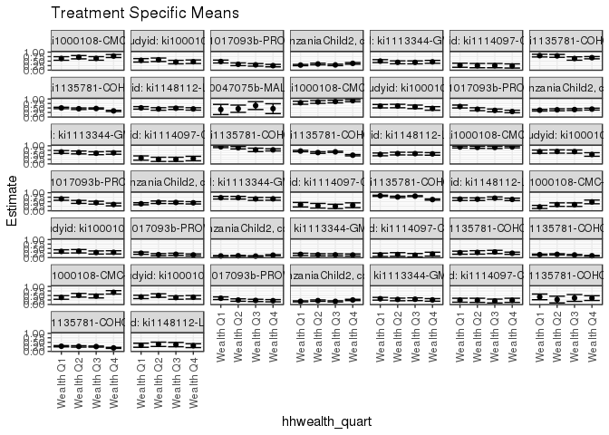

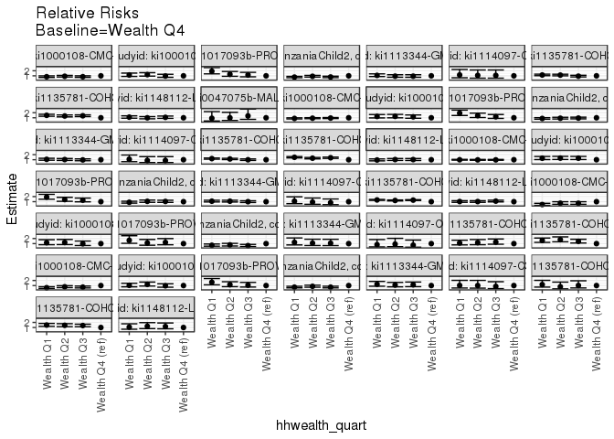

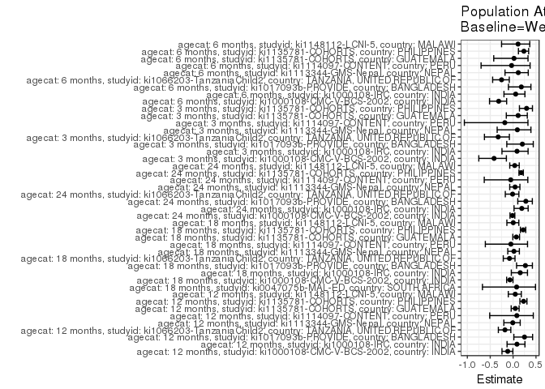

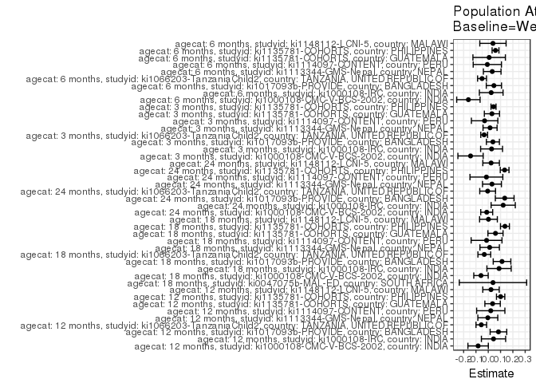

## Results Table

### Parameter: TSM

| agecat | studyid | country | intervention_level | baseline_level | estimate | ci_lower | ci_upper |
| --- | --- | --- | --- | --- | --- | --- | --- |
| 3 months | ki1000108-CMC-V-BCS-2002 | INDIA | Wealth Q4 | NA | 0.4891304 | 0.3868430 | 0.5914179 |
| 3 months | ki1000108-CMC-V-BCS-2002 | INDIA | Wealth Q1 | NA | 0.2111111 | 0.1266822 | 0.2955400 |
| 3 months | ki1000108-CMC-V-BCS-2002 | INDIA | Wealth Q2 | NA | 0.3406593 | 0.2431507 | 0.4381680 |
| 3 months | ki1000108-CMC-V-BCS-2002 | INDIA | Wealth Q3 | NA | 0.3370787 | 0.2387341 | 0.4354232 |
| 3 months | ki1000108-IRC | INDIA | Wealth Q4 | NA | 0.2900000 | 0.2009556 | 0.3790444 |
| 3 months | ki1000108-IRC | INDIA | Wealth Q1 | NA | 0.3428571 | 0.2519558 | 0.4337585 |
| 3 months | ki1000108-IRC | INDIA | Wealth Q2 | NA | 0.3529412 | 0.2600870 | 0.4457953 |
| 3 months | ki1000108-IRC | INDIA | Wealth Q3 | NA | 0.2815534 | 0.1945898 | 0.3685170 |
| 3 months | ki1017093b-PROVIDE | BANGLADESH | Wealth Q4 | NA | 0.1485714 | 0.0958385 | 0.2013044 |
| 3 months | ki1017093b-PROVIDE | BANGLADESH | Wealth Q1 | NA | 0.2444444 | 0.1816174 | 0.3072715 |
| 3 months | ki1017093b-PROVIDE | BANGLADESH | Wealth Q2 | NA | 0.1656805 | 0.1095863 | 0.2217747 |
| 3 months | ki1017093b-PROVIDE | BANGLADESH | Wealth Q3 | NA | 0.1839080 | 0.1263038 | 0.2415123 |
| 3 months | ki1066203-TanzaniaChild2 | TANZANIA, UNITED REPUBLIC OF | Wealth Q4 | NA | 0.1353638 | 0.1077762 | 0.1629514 |
| 3 months | ki1066203-TanzaniaChild2 | TANZANIA, UNITED REPUBLIC OF | Wealth Q1 | NA | 0.0919220 | 0.0707848 | 0.1130593 |
| 3 months | ki1066203-TanzaniaChild2 | TANZANIA, UNITED REPUBLIC OF | Wealth Q2 | NA | 0.1014493 | 0.0745177 | 0.1283808 |
| 3 months | ki1066203-TanzaniaChild2 | TANZANIA, UNITED REPUBLIC OF | Wealth Q3 | NA | 0.0814941 | 0.0593944 | 0.1035937 |
| 3 months | ki1113344-GMS-Nepal | NEPAL | Wealth Q4 | NA | 0.1438356 | 0.0868651 | 0.2008061 |
| 3 months | ki1113344-GMS-Nepal | NEPAL | Wealth Q1 | NA | 0.1800000 | 0.1184664 | 0.2415336 |
| 3 months | ki1113344-GMS-Nepal | NEPAL | Wealth Q2 | NA | 0.1554054 | 0.0969882 | 0.2138226 |
| 3 months | ki1113344-GMS-Nepal | NEPAL | Wealth Q3 | NA | 0.1543624 | 0.0963014 | 0.2124234 |
| 3 months | ki1114097-CONTENT | PERU | Wealth Q4 | NA | 0.1923077 | 0.0849384 | 0.2996770 |
| 3 months | ki1114097-CONTENT | PERU | Wealth Q1 | NA | 0.1525424 | 0.0605846 | 0.2445002 |
| 3 months | ki1114097-CONTENT | PERU | Wealth Q2 | NA | 0.1730769 | 0.0700120 | 0.2761419 |
| 3 months | ki1114097-CONTENT | PERU | Wealth Q3 | NA | 0.1346154 | 0.0416309 | 0.2275999 |
| 3 months | ki1135781-COHORTS | GUATEMALA | Wealth Q4 | NA | 0.2419355 | 0.1803263 | 0.3035447 |
| 3 months | ki1135781-COHORTS | GUATEMALA | Wealth Q1 | NA | 0.2710280 | 0.1867199 | 0.3553362 |
| 3 months | ki1135781-COHORTS | GUATEMALA | Wealth Q2 | NA | 0.2873563 | 0.1921675 | 0.3825452 |
| 3 months | ki1135781-COHORTS | GUATEMALA | Wealth Q3 | NA | 0.3137255 | 0.2235844 | 0.4038666 |
| 3 months | ki1135781-COHORTS | PHILIPPINES | Wealth Q4 | NA | 0.1020166 | 0.0815816 | 0.1224516 |
| 3 months | ki1135781-COHORTS | PHILIPPINES | Wealth Q1 | NA | 0.1644833 | 0.1367578 | 0.1922088 |

[output cut: 146 more lines]

### Parameter: E(Y)

| agecat | studyid | country | intervention_level | baseline_level | estimate | ci_lower | ci_upper |
| --- | --- | --- | --- | --- | --- | --- | --- |
| 3 months | ki1000108-CMC-V-BCS-2002 | INDIA | NA | NA | 0.3453039 | 0.3351147 | 0.3554930 |
| 3 months | ki1000108-IRC | INDIA | NA | NA | 0.3170732 | 0.3140300 | 0.3201164 |
| 3 months | ki1017093b-PROVIDE | BANGLADESH | NA | NA | 0.1862464 | 0.1835359 | 0.1889570 |
| 3 months | ki1066203-TanzaniaChild2 | TANZANIA, UNITED REPUBLIC OF | NA | NA | 0.1020580 | 0.1012435 | 0.1028724 |
| 3 months | ki1113344-GMS-Nepal | NEPAL | NA | NA | 0.1585160 | 0.1574456 | 0.1595864 |
| 3 months | ki1114097-CONTENT | PERU | NA | NA | 0.1627907 | 0.1599261 | 0.1656553 |
| 3 months | ki1135781-COHORTS | GUATEMALA | NA | NA | 0.2717842 | 0.2693206 | 0.2742478 |
| 3 months | ki1135781-COHORTS | PHILIPPINES | NA | NA | 0.1446809 | 0.1436602 | 0.1457015 |
| 6 months | ki1000108-CMC-V-BCS-2002 | INDIA | NA | NA | 0.5122616 | 0.5015225 | 0.5230007 |
| 6 months | ki1000108-IRC | INDIA | NA | NA | 0.4240196 | 0.4198628 | 0.4281765 |
| 6 months | ki1017093b-PROVIDE | BANGLADESH | NA | NA | 0.2554859 | 0.2513616 | 0.2596102 |
| 6 months | ki1066203-TanzaniaChild2 | TANZANIA, UNITED REPUBLIC OF | NA | NA | 0.2000000 | 0.1986313 | 0.2013687 |
| 6 months | ki1113344-GMS-Nepal | NEPAL | NA | NA | 0.2857143 | 0.2838136 | 0.2876149 |
| 6 months | ki1114097-CONTENT | PERU | NA | NA | 0.2232558 | 0.2208855 | 0.2256261 |
| 6 months | ki1135781-COHORTS | GUATEMALA | NA | NA | 0.3602941 | 0.3522180 | 0.3683703 |
| 6 months | ki1135781-COHORTS | PHILIPPINES | NA | NA | 0.2499109 | 0.2485453 | 0.2512764 |
| 6 months | ki1148112-LCNI-5 | MALAWI | NA | NA | 0.3531599 | 0.3495731 | 0.3567466 |
| 12 months | ki1000108-CMC-V-BCS-2002 | INDIA | NA | NA | 0.6989247 | 0.6931997 | 0.7046497 |
| 12 months | ki1000108-IRC | INDIA | NA | NA | 0.5073529 | 0.5022060 | 0.5124999 |
| 12 months | ki1017093b-PROVIDE | BANGLADESH | NA | NA | 0.3327842 | 0.3260604 | 0.3395079 |
| 12 months | ki1066203-TanzaniaChild2 | TANZANIA, UNITED REPUBLIC OF | NA | NA | 0.3174044 | 0.3157037 | 0.3191051 |
| 12 months | ki1113344-GMS-Nepal | NEPAL | NA | NA | 0.4553265 | 0.4530054 | 0.4576475 |
| 12 months | ki1114097-CONTENT | PERU | NA | NA | 0.2511628 | 0.2492154 | 0.2531102 |
| 12 months | ki1135781-COHORTS | GUATEMALA | NA | NA | 0.7238095 | 0.7184427 | 0.7291763 |
| 12 months | ki1135781-COHORTS | PHILIPPINES | NA | NA | 0.4388125 | 0.4364440 | 0.4411809 |
| 12 months | ki1148112-LCNI-5 | MALAWI | NA | NA | 0.4710327 | 0.4692728 | 0.4727927 |
| 18 months | ki0047075b-MAL-ED | SOUTH AFRICA | NA | NA | 0.5000000 | 0.4800258 | 0.5199742 |
| 18 months | ki1000108-CMC-V-BCS-2002 | INDIA | NA | NA | 0.8471850 | 0.8429357 | 0.8514343 |
| 18 months | ki1000108-IRC | INDIA | NA | NA | 0.5623472 | 0.5572701 | 0.5674243 |
| 18 months | ki1017093b-PROVIDE | BANGLADESH | NA | NA | 0.4162521 | 0.4080933 | 0.4244109 |
| 18 months | ki1066203-TanzaniaChild2 | TANZANIA, UNITED REPUBLIC OF | NA | NA | 0.4053867 | 0.4042515 | 0.4065219 |
| 18 months | ki1113344-GMS-Nepal | NEPAL | NA | NA | 0.6236934 | 0.6216021 | 0.6257847 |
| 18 months | ki1114097-CONTENT | PERU | NA | NA | 0.2803738 | 0.2761872 | 0.2845604 |
| 18 months | ki1135781-COHORTS | GUATEMALA | NA | NA | 0.8352668 | 0.8283315 | 0.8422021 |
| 18 months | ki1135781-COHORTS | PHILIPPINES | NA | NA | 0.6166413 | 0.6132587 | 0.6200240 |
| 18 months | ki1148112-LCNI-5 | MALAWI | NA | NA | 0.5535714 | 0.5522534 | 0.5548895 |
| 24 months | ki1000108-CMC-V-BCS-2002 | INDIA | NA | NA | 0.9249330 | 0.9238081 | 0.9260579 |
| 24 months | ki1000108-IRC | INDIA | NA | NA | 0.6414634 | 0.6347684 | 0.6481585 |
| 24 months | ki1017093b-PROVIDE | BANGLADESH | NA | NA | 0.4802065 | 0.4711165 | 0.4892966 |
| 24 months | ki1066203-TanzaniaChild2 | TANZANIA, UNITED REPUBLIC OF | NA | NA | 0.4342380 | 0.4321350 | 0.4363410 |
| 24 months | ki1113344-GMS-Nepal | NEPAL | NA | NA | 0.6901408 | 0.6875504 | 0.6927312 |
| 24 months | ki1114097-CONTENT | PERU | NA | NA | 0.2893401 | 0.2844108 | 0.2942694 |
| 24 months | ki1135781-COHORTS | PHILIPPINES | NA | NA | 0.7525371 | 0.7491897 | 0.7558844 |
| 24 months | ki1148112-LCNI-5 | MALAWI | NA | NA | 0.6513889 | 0.6494462 | 0.6533316 |

### Parameter: RR

| agecat | studyid | country | intervention_level | baseline_level | estimate | ci_lower | ci_upper |
| --- | --- | --- | --- | --- | --- | --- | --- |
| 3 months | ki1000108-CMC-V-BCS-2002 | INDIA | Wealth Q4 | Wealth Q4 | 1.0000000 | 1.0000000 | 1.0000000 |
| 3 months | ki1000108-CMC-V-BCS-2002 | INDIA | Wealth Q1 | Wealth Q4 | 0.4316049 | 0.2748457 | 0.6777725 |
| 3 months | ki1000108-CMC-V-BCS-2002 | INDIA | Wealth Q2 | Wealth Q4 | 0.6964591 | 0.4885885 | 0.9927686 |
| 3 months | ki1000108-CMC-V-BCS-2002 | INDIA | Wealth Q3 | Wealth Q4 | 0.6891386 | 0.4812956 | 0.9867367 |
| 3 months | ki1000108-IRC | INDIA | Wealth Q4 | Wealth Q4 | 1.0000000 | 1.0000000 | 1.0000000 |
| 3 months | ki1000108-IRC | INDIA | Wealth Q1 | Wealth Q4 | 1.1822660 | 0.7880114 | 1.7737725 |
| 3 months | ki1000108-IRC | INDIA | Wealth Q2 | Wealth Q4 | 1.2170385 | 0.8122691 | 1.8235124 |
| 3 months | ki1000108-IRC | INDIA | Wealth Q3 | Wealth Q4 | 0.9708738 | 0.6280836 | 1.5007492 |
| 3 months | ki1017093b-PROVIDE | BANGLADESH | Wealth Q4 | Wealth Q4 | 1.0000000 | 1.0000000 | 1.0000000 |
| 3 months | ki1017093b-PROVIDE | BANGLADESH | Wealth Q1 | Wealth Q4 | 1.6452991 | 1.0615204 | 2.5501247 |
| 3 months | ki1017093b-PROVIDE | BANGLADESH | Wealth Q2 | Wealth Q4 | 1.1151570 | 0.6828219 | 1.8212292 |
| 3 months | ki1017093b-PROVIDE | BANGLADESH | Wealth Q3 | Wealth Q4 | 1.2378426 | 0.7710456 | 1.9872421 |
| 3 months | ki1066203-TanzaniaChild2 | TANZANIA, UNITED REPUBLIC OF | Wealth Q4 | Wealth Q4 | 1.0000000 | 1.0000000 | 1.0000000 |
| 3 months | ki1066203-TanzaniaChild2 | TANZANIA, UNITED REPUBLIC OF | Wealth Q1 | Wealth Q4 | 0.6790738 | 0.4994288 | 0.9233373 |
| 3 months | ki1066203-TanzaniaChild2 | TANZANIA, UNITED REPUBLIC OF | Wealth Q2 | Wealth Q4 | 0.7494565 | 0.5362876 | 1.0473579 |
| 3 months | ki1066203-TanzaniaChild2 | TANZANIA, UNITED REPUBLIC OF | Wealth Q3 | Wealth Q4 | 0.6020374 | 0.4288436 | 0.8451774 |
| 3 months | ki1113344-GMS-Nepal | NEPAL | Wealth Q4 | Wealth Q4 | 1.0000000 | 1.0000000 | 1.0000000 |
| 3 months | ki1113344-GMS-Nepal | NEPAL | Wealth Q1 | Wealth Q4 | 1.2514286 | 0.7416193 | 2.1116945 |
| 3 months | ki1113344-GMS-Nepal | NEPAL | Wealth Q2 | Wealth Q4 | 1.0804376 | 0.6258187 | 1.8653091 |
| 3 months | ki1113344-GMS-Nepal | NEPAL | Wealth Q3 | Wealth Q4 | 1.0731863 | 0.6215193 | 1.8530863 |
| 3 months | ki1114097-CONTENT | PERU | Wealth Q4 | Wealth Q4 | 1.0000000 | 1.0000000 | 1.0000000 |
| 3 months | ki1114097-CONTENT | PERU | Wealth Q1 | Wealth Q4 | 0.7932203 | 0.3487786 | 1.8040053 |
| 3 months | ki1114097-CONTENT | PERU | Wealth Q2 | Wealth Q4 | 0.9000000 | 0.3978628 | 2.0358778 |
| 3 months | ki1114097-CONTENT | PERU | Wealth Q3 | Wealth Q4 | 0.7000000 | 0.2879855 | 1.7014746 |
| 3 months | ki1135781-COHORTS | GUATEMALA | Wealth Q4 | Wealth Q4 | 1.0000000 | 1.0000000 | 1.0000000 |
| 3 months | ki1135781-COHORTS | GUATEMALA | Wealth Q1 | Wealth Q4 | 1.1202492 | 0.7494190 | 1.6745751 |
| 3 months | ki1135781-COHORTS | GUATEMALA | Wealth Q2 | Wealth Q4 | 1.1877395 | 0.7820988 | 1.8037682 |
| 3 months | ki1135781-COHORTS | GUATEMALA | Wealth Q3 | Wealth Q4 | 1.2967320 | 0.8833061 | 1.9036593 |
| 3 months | ki1135781-COHORTS | PHILIPPINES | Wealth Q4 | Wealth Q4 | 1.0000000 | 1.0000000 | 1.0000000 |
| 3 months | ki1135781-COHORTS | PHILIPPINES | Wealth Q1 | Wealth Q4 | 1.6123185 | 1.2409497 | 2.0948236 |

[output cut: 146 more lines]

### Parameter: PAR

| agecat | studyid | country | intervention_level | baseline_level | estimate | ci_lower | ci_upper |
| --- | --- | --- | --- | --- | --- | --- | --- |
| 3 months | ki1000108-CMC-V-BCS-2002 | INDIA | Wealth Q4 | NA | -0.1438266 | -0.2466202 | -0.0410329 |
| 3 months | ki1000108-IRC | INDIA | Wealth Q4 | NA | 0.0270732 | -0.0620232 | 0.1161695 |
| 3 months | ki1017093b-PROVIDE | BANGLADESH | Wealth Q4 | NA | 0.0376750 | -0.0151276 | 0.0904776 |
| 3 months | ki1066203-TanzaniaChild2 | TANZANIA, UNITED REPUBLIC OF | Wealth Q4 | NA | -0.0333058 | -0.0609054 | -0.0057062 |
| 3 months | ki1113344-GMS-Nepal | NEPAL | Wealth Q4 | NA | 0.0146804 | -0.0423001 | 0.0716609 |
| 3 months | ki1114097-CONTENT | PERU | Wealth Q4 | NA | -0.0295170 | -0.1369245 | 0.0778905 |
| 3 months | ki1135781-COHORTS | GUATEMALA | Wealth Q4 | NA | 0.0298487 | -0.0318097 | 0.0915072 |
| 3 months | ki1135781-COHORTS | PHILIPPINES | Wealth Q4 | NA | 0.0426642 | 0.0222038 | 0.0631247 |
| 6 months | ki1000108-CMC-V-BCS-2002 | INDIA | Wealth Q4 | NA | -0.1614226 | -0.2564432 | -0.0664021 |
| 6 months | ki1000108-IRC | INDIA | Wealth Q4 | NA | 0.0240196 | -0.0722063 | 0.1202456 |
| 6 months | ki1017093b-PROVIDE | BANGLADESH | Wealth Q4 | NA | 0.0459051 | -0.0160106 | 0.1078207 |
| 6 months | ki1066203-TanzaniaChild2 | TANZANIA, UNITED REPUBLIC OF | Wealth Q4 | NA | -0.0504537 | -0.0866650 | -0.0142425 |
| 6 months | ki1113344-GMS-Nepal | NEPAL | Wealth Q4 | NA | 0.0321932 | -0.0394469 | 0.1038332 |
| 6 months | ki1114097-CONTENT | PERU | Wealth Q4 | NA | -0.0075134 | -0.1223205 | 0.1072936 |
| 6 months | ki1135781-COHORTS | GUATEMALA | Wealth Q4 | NA | 0.0073529 | -0.1245348 | 0.1392407 |
| 6 months | ki1135781-COHORTS | PHILIPPINES | Wealth Q4 | NA | 0.0590018 | 0.0312036 | 0.0868000 |
| 6 months | ki1148112-LCNI-5 | MALAWI | Wealth Q4 | NA | 0.0380914 | -0.0687320 | 0.1449148 |
| 12 months | ki1000108-CMC-V-BCS-2002 | INDIA | Wealth Q4 | NA | -0.0823253 | -0.1653297 | 0.0006792 |
| 12 months | ki1000108-IRC | INDIA | Wealth Q4 | NA | 0.0427065 | -0.0557941 | 0.1412070 |
| 12 months | ki1017093b-PROVIDE | BANGLADESH | Wealth Q4 | NA | 0.0827842 | 0.0152983 | 0.1502701 |
| 12 months | ki1066203-TanzaniaChild2 | TANZANIA, UNITED REPUBLIC OF | Wealth Q4 | NA | -0.0565625 | -0.0997132 | -0.0134119 |
| 12 months | ki1113344-GMS-Nepal | NEPAL | Wealth Q4 | NA | -0.0035776 | -0.0845099 | 0.0773546 |
| 12 months | ki1114097-CONTENT | PERU | Wealth Q4 | NA | 0.0203936 | -0.0944056 | 0.1351927 |
| 12 months | ki1135781-COHORTS | GUATEMALA | Wealth Q4 | NA | 0.0351303 | -0.0274889 | 0.0977495 |
| 12 months | ki1135781-COHORTS | PHILIPPINES | Wealth Q4 | NA | 0.1006354 | 0.0668452 | 0.1344257 |
| 12 months | ki1148112-LCNI-5 | MALAWI | Wealth Q4 | NA | 0.0224346 | -0.0442659 | 0.0891351 |
| 18 months | ki0047075b-MAL-ED | SOUTH AFRICA | Wealth Q4 | NA | 0.0384615 | -0.2352758 | 0.3121989 |
| 18 months | ki1000108-CMC-V-BCS-2002 | INDIA | Wealth Q4 | NA | -0.0590650 | -0.1176049 | -0.0005251 |
| 18 months | ki1000108-IRC | INDIA | Wealth Q4 | NA | 0.0875997 | -0.0110177 | 0.1862172 |
| 18 months | ki1017093b-PROVIDE | BANGLADESH | Wealth Q4 | NA | 0.1119042 | 0.0403040 | 0.1835045 |
| 18 months | ki1066203-TanzaniaChild2 | TANZANIA, UNITED REPUBLIC OF | Wealth Q4 | NA | -0.0321133 | -0.0839671 | 0.0197406 |
| 18 months | ki1113344-GMS-Nepal | NEPAL | Wealth Q4 | NA | 0.0114485 | -0.0674125 | 0.0903095 |
| 18 months | ki1114097-CONTENT | PERU | Wealth Q4 | NA | -0.0137438 | -0.1391586 | 0.1116710 |
| 18 months | ki1135781-COHORTS | GUATEMALA | Wealth Q4 | NA | 0.0587305 | -0.0027575 | 0.1202185 |
| 18 months | ki1135781-COHORTS | PHILIPPINES | Wealth Q4 | NA | 0.1356115 | 0.0993987 | 0.1718244 |
| 18 months | ki1148112-LCNI-5 | MALAWI | Wealth Q4 | NA | 0.0016589 | -0.0704577 | 0.0737754 |
| 24 months | ki1000108-CMC-V-BCS-2002 | INDIA | Wealth Q4 | NA | -0.0125670 | -0.0610666 | 0.0359325 |
| 24 months | ki1000108-IRC | INDIA | Wealth Q4 | NA | 0.1214634 | 0.0231957 | 0.2197312 |
| 24 months | ki1017093b-PROVIDE | BANGLADESH | Wealth Q4 | NA | 0.1338013 | 0.0577947 | 0.2098079 |
| 24 months | ki1066203-TanzaniaChild2 | TANZANIA, UNITED REPUBLIC OF | Wealth Q4 | NA | -0.0048924 | -0.0690979 | 0.0593130 |
| 24 months | ki1113344-GMS-Nepal | NEPAL | Wealth Q4 | NA | 0.0302769 | -0.0464192 | 0.1069730 |
| 24 months | ki1114097-CONTENT | PERU | Wealth Q4 | NA | -0.0150077 | -0.1484066 | 0.1183911 |
| 24 months | ki1135781-COHORTS | PHILIPPINES | Wealth Q4 | NA | 0.1330316 | 0.0975984 | 0.1684648 |
| 24 months | ki1148112-LCNI-5 | MALAWI | Wealth Q4 | NA | 0.0232482 | -0.0439755 | 0.0904719 |

### Parameter: PAF

| agecat | studyid | country | intervention_level | baseline_level | estimate | ci_lower | ci_upper |
| --- | --- | --- | --- | --- | --- | --- | --- |
| 3 months | ki1000108-CMC-V-BCS-2002 | INDIA | Wealth Q4 | NA | -0.4165217 | -0.7496170 | -0.1468418 |
| 3 months | ki1000108-IRC | INDIA | Wealth Q4 | NA | 0.0853846 | -0.2435223 | 0.3272969 |
| 3 months | ki1017093b-PROVIDE | BANGLADESH | Wealth Q4 | NA | 0.2022857 | -0.1379482 | 0.4407935 |
| 3 months | ki1066203-TanzaniaChild2 | TANZANIA, UNITED REPUBLIC OF | Wealth Q4 | NA | -0.3263423 | -0.6264251 | -0.0816262 |
| 3 months | ki1113344-GMS-Nepal | NEPAL | Wealth Q4 | NA | 0.0926115 | -0.3484470 | 0.3894058 |
| 3 months | ki1114097-CONTENT | PERU | Wealth Q4 | NA | -0.1813187 | -1.0652037 | 0.3242730 |
| 3 months | ki1135781-COHORTS | GUATEMALA | Wealth Q4 | NA | 0.1098252 | -0.1485212 | 0.3100595 |
| 3 months | ki1135781-COHORTS | PHILIPPINES | Wealth Q4 | NA | 0.2948852 | 0.1383962 | 0.4229518 |
| 6 months | ki1000108-CMC-V-BCS-2002 | INDIA | Wealth Q4 | NA | -0.3151176 | -0.5153218 | -0.1413643 |
| 6 months | ki1000108-IRC | INDIA | Wealth Q4 | NA | 0.0566474 | -0.1998841 | 0.2583333 |
| 6 months | ki1017093b-PROVIDE | BANGLADESH | Wealth Q4 | NA | 0.1796775 | -0.1020302 | 0.3893733 |
| 6 months | ki1066203-TanzaniaChild2 | TANZANIA, UNITED REPUBLIC OF | Wealth Q4 | NA | -0.2522686 | -0.4471527 | -0.0836290 |
| 6 months | ki1113344-GMS-Nepal | NEPAL | Wealth Q4 | NA | 0.1126761 | -0.1770531 | 0.3310890 |
| 6 months | ki1114097-CONTENT | PERU | Wealth Q4 | NA | -0.0336538 | -0.6999596 | 0.3714908 |
| 6 months | ki1135781-COHORTS | GUATEMALA | Wealth Q4 | NA | 0.0204082 | -0.4233800 | 0.3258299 |
| 6 months | ki1135781-COHORTS | PHILIPPINES | Wealth Q4 | NA | 0.2360913 | 0.1164174 | 0.3395563 |
| 6 months | ki1148112-LCNI-5 | MALAWI | Wealth Q4 | NA | 0.1078587 | -0.2521705 | 0.3643708 |
| 12 months | ki1000108-CMC-V-BCS-2002 | INDIA | Wealth Q4 | NA | -0.1177885 | -0.2431654 | -0.0050561 |
| 12 months | ki1000108-IRC | INDIA | Wealth Q4 | NA | 0.0841751 | -0.1320313 | 0.2590882 |
| 12 months | ki1017093b-PROVIDE | BANGLADESH | Wealth Q4 | NA | 0.2487624 | 0.0165357 | 0.4261531 |
| 12 months | ki1066203-TanzaniaChild2 | TANZANIA, UNITED REPUBLIC OF | Wealth Q4 | NA | -0.1782033 | -0.3223517 | -0.0497684 |
| 12 months | ki1113344-GMS-Nepal | NEPAL | Wealth Q4 | NA | -0.0078573 | -0.2022414 | 0.1550978 |
| 12 months | ki1114097-CONTENT | PERU | Wealth Q4 | NA | 0.0811966 | -0.5109953 | 0.4412956 |
| 12 months | ki1135781-COHORTS | GUATEMALA | Wealth Q4 | NA | 0.0485353 | -0.0420003 | 0.1312045 |
| 12 months | ki1135781-COHORTS | PHILIPPINES | Wealth Q4 | NA | 0.2293359 | 0.1484385 | 0.3025481 |
| 12 months | ki1148112-LCNI-5 | MALAWI | Wealth Q4 | NA | 0.0476286 | -0.1050400 | 0.1792049 |
| 18 months | ki0047075b-MAL-ED | SOUTH AFRICA | Wealth Q4 | NA | 0.0769231 | -0.6699960 | 0.4897766 |
| 18 months | ki1000108-CMC-V-BCS-2002 | INDIA | Wealth Q4 | NA | -0.0697191 | -0.1411271 | -0.0027796 |
| 18 months | ki1000108-IRC | INDIA | Wealth Q4 | NA | 0.1557751 | -0.0390539 | 0.3140726 |
| 18 months | ki1017093b-PROVIDE | BANGLADESH | Wealth Q4 | NA | 0.2688377 | 0.0755660 | 0.4217020 |
| 18 months | ki1066203-TanzaniaChild2 | TANZANIA, UNITED REPUBLIC OF | Wealth Q4 | NA | -0.0792164 | -0.2150230 | 0.0414108 |
| 18 months | ki1113344-GMS-Nepal | NEPAL | Wealth Q4 | NA | 0.0183559 | -0.1165886 | 0.1369918 |
| 18 months | ki1114097-CONTENT | PERU | Wealth Q4 | NA | -0.0490196 | -0.6068734 | 0.3151656 |
| 18 months | ki1135781-COHORTS | GUATEMALA | Wealth Q4 | NA | 0.0703135 | -0.0062255 | 0.1410305 |
| 18 months | ki1135781-COHORTS | PHILIPPINES | Wealth Q4 | NA | 0.2199196 | 0.1590349 | 0.2763964 |
| 18 months | ki1148112-LCNI-5 | MALAWI | Wealth Q4 | NA | 0.0029967 | -0.1361727 | 0.1251192 |
| 24 months | ki1000108-CMC-V-BCS-2002 | INDIA | Wealth Q4 | NA | -0.0135870 | -0.0674032 | 0.0375159 |
| 24 months | ki1000108-IRC | INDIA | Wealth Q4 | NA | 0.1893536 | 0.0208764 | 0.3288411 |
| 24 months | ki1017093b-PROVIDE | BANGLADESH | Wealth Q4 | NA | 0.2786328 | 0.1023237 | 0.4203138 |
| 24 months | ki1066203-TanzaniaChild2 | TANZANIA, UNITED REPUBLIC OF | Wealth Q4 | NA | -0.0112667 | -0.1704823 | 0.1262915 |
| 24 months | ki1113344-GMS-Nepal | NEPAL | Wealth Q4 | NA | 0.0438706 | -0.0739705 | 0.1487816 |
| 24 months | ki1114097-CONTENT | PERU | Wealth Q4 | NA | -0.0518688 | -0.6305393 | 0.3214343 |
| 24 months | ki1135781-COHORTS | PHILIPPINES | Wealth Q4 | NA | 0.1767774 | 0.1283916 | 0.2224772 |
| 24 months | ki1148112-LCNI-5 | MALAWI | Wealth Q4 | NA | 0.0356902 | -0.0732317 | 0.1335576 |